# 3.Alineamientos_intro_practica

[figure not shown]

## **Introducció a la Bioinformàtica**

Toni Monleon-Getino. 2016

[figure not shown]

🌐INTRODUCCIÓ A LA BIOINFORMÀTICA (8h)

- Introducció (dia 1)
- Bases de dades (dia 1)
- **Alineament de sequències (dia1 / dia2)**
- Cerques per Similitud (dia 2 / dia 3)
- Next Generation Sequenting (NGS) (dia 3 / dia 4)
- Gene Expression Omnibus database (GEO) (dia 4)

## ALINEAMENT DE SEQÜÈNCIES

En aquesta sessió s’explicarà com s’alineen seqüències, tant d’ADN (nucleòtids) com de proteïnes (aminoàcids). Es presentaran diferents tipus d’alineament, així com els contextos i objectius per als que es fan servir. Al final de la secció ens centrarem en l’alineament de dues seqüències.

# INTRODUCCIÓ ALS ALINEAMENTS DE SEQÜÈNCIES

L'alineament de seqüències és un dels temes més rellevants i clàssics de la bioinformàtica. Consisteix en comparar dues o més seqüències biològiques (ADN, ARN o proteïnes) per identificar regions de similitud que poden indicar relacions funcionals, estructurals o evolutives (Veure mes a : https://students.aertslab.org/ebook/chapter6_alignments.html)

[figure not shown]

## Tipus d'alineaments

Cal distingir entre diferents tipus d'alineaments segons el nombre de seqüències que es comparen:

- **Comparació de dues seqüències (Pairwise Sequence Alignment o PSA):** Aquest tipus d'alineament compara dues seqüències entre si per trobar regions de similitud. És la base per a molts altres tipus d'anàlisis.

[figure not shown]

- **Comparació d'una seqüència contra les d'una base de dades (PSA massiu):** En aquest cas, una seqüència de consulta es compara amb totes les seqüències d'una base de dades per identificar seqüències similars. Aquesta tècnica s'utilitza, per exemple, per identificar la funció d'una seqüència nova o per trobar homòlegs en altres organismes.

[figure not shown]

- **Comparació de *n* seqüències simultàniament (Multiple Sequence Alignment o MSA):** Aquest tipus d'alineament compara tres o més seqüències alhora per identificar regions conservades entre totes elles. Els MSA són útils per a estudiar famílies de proteïnes, reconstruir filogènies o identificar motius conservats.

[figure not shown]

## **Justificació biològica**

La idea bàsica és que seqüències semblants solen tenir funcions semblants degudes a homologies evolutives. Aquestes homologies suggereixen un origen evolutiu comú i, per tant, una possible similitud en la funció o estructura de les molècules que codifiquen.

## Exemple senzill (PSA)

Imaginem que tenim les següents dues seqüències d'ADN:

Seqüència 1: `GATTACA` Seqüència 2: `GATTAGA`

Un possible alineament seria:

| G | A | T | T | A | C | A |
| --- | --- | --- | --- | --- | --- | --- |
| \| | \| | \| | \| | \| |  | \| |
| G | A | T | T | A | G | A |

## Aplicacions

Els alineaments de seqüències tenen una gran varietat d'aplicacions en bioinformàtica, com ara:

- **Predicció de la funció de gens i proteïnes.**
- **Estudis evolutius i filogenètics.**
- **Identificació de motius conservats.**
- **Diagnòstic de malalties.**
- **Disseny de fàrmacs.**

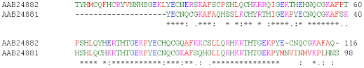

## El procés biològic darrere l'alineament de seqüències

Quan comparem seqüències biològiques (ADN, ARN o proteïnes), pretenem representar el procés evolutiu de divergència que es dona degut a les mutacions i la selecció natural a partir d'un ancestre comú. Aquest ancestre comú és la seqüència hipotètica a partir de la qual han evolucionat les seqüències que observem avui dia.

[figure not shown]

### Processos mutacionals bàsics

Els principals processos mutacionals que influeixen en les diferències entre seqüències són:

- **Substitucions:** Canvis d'una base o aminoàcid per un altre en una posició determinada de la seqüència. Aquests canvis es representen com *mismatches* (no coincidències) en un alineament.
- **Insercions / Delecions (indels):** Addició o pèrdua d'una o més bases o aminoàcids. Es representen amb *forats* o *gaps* (-) en l'alineament.

### Representació del procés evolutiu

Quan alineem seqüències, intentem reconstruir o representar aquest procés evolutiu des del moment de la divergència a partir de l'ancestre comú. És crucial tenir en compte que les diferències que observem entre dues o més seqüències contemporànies (que existeixen al mateix temps) són el resultat de canvis que han acumulat *des de l'ancestre comú*, i no canvis directes entre elles.

### Esquema del procés evolutiu

L'esquema següent il·lustra la relació entre l'ancestre comú i les seqüències descendents:

| [Ancestre Comú] |
| --- |
| ↓ |
| Mutacions (Substitucions, Insercions, Delecions) |
| ↓ |
| [Seqüència 1] [Seqüència 2] |

### Exemple teòric

Per entendre millor aquest concepte, considerem un exemple teòric amb seqüències d'ADN:

**Cas 1: Deleció**

- Ancestre comú: `AATT` (aquesta seqüència no la tenim directament)
- Seqüències descendents:
  - Deleció (s'ha eliminat la primera o la segona A): `ATT`
  - (Sense canvis): `AATT`

**Cas 2: Inserció**

- Ancestre comú: `ATT`
- Seqüències descendents:
  - (Sense canvis): `ATT`
  - Inserció (s'ha afegit la segona A): `AATT`

**Conclusió de l'exemple**

Si només disposem de les seqüències `ATT` i `AATT`, no podem determinar amb certesa si l'ancestre comú era `AATT` (amb una deleció posterior) o `ATT` (amb una inserció posterior). L'alineament de seqüències ens permet comparar les seqüències i proposar les hipòtesis evolutives més probables, però no sempre podem reconstruir la història evolutiva completa només amb la informació de les seqüències actuals.

### Resum dels conceptes clau:

- Les diferències entre seqüències reflecteixen canvis acumulats des d'un ancestre comú.
- Els principals tipus de canvis evolutius són les substitucions, les insercions i les delecions (indels).
- L'alineament de seqüències ens ajuda a inferir relacions evolutives, però la reconstrucció exacta de la història evolutiva pot ser complexa.

# Pairwise Sequence Alignments (PSA) - Alineaments de Seqüències de Parells

Els Pairwise Sequence Alignments (PSA) o Alineaments de Seqüències de Parells s'utilitzen per comparar dues seqüències biològiques (ADN, ARN o proteïnes) amb l'objectiu d'identificar regions de similitud que puguin indicar relacions funcionals, estructurals o evolutives.

[figure not shown]

## Objectius del PSA

L'objectiu principal d'un PSA és:

- **Maximitzar el nombre de coincidències (matches):** Trobar la major quantitat possible de caràcters idèntics a la mateixa columna.
- **Minimitzar les substitucions (mismatches):** Reduir al mínim els canvis d'un caràcter per un altre a la mateixa columna.
- **Minimitzar les insercions i delecions (indels o gaps):** Minimitzar la introducció d'espais (gaps) a les seqüències per aconseguir el millor alineament.

## Exemple pràctic

Considerem les següents dues seqüències:

- Seq A: `LGPSKSQGTKGSSRIWDN`
- Seq B: `IKTSGAKGAIMRLGDA`

Un possible alineament podria ser:

```
LGPSKSQGTKGS-SRIWDN
.|:.|.||: .|:.|.
IKTSGAKGAIMRLGDA
```

## Què és un alineament de seqüències?

Un alineament de seqüències consisteix a col·locar una seqüència sota l'altra de tal manera que s'ha de posar (o no) un *gap* o varis *gaps* (simbolitzats amb una ratlla "-") entre dues bases o aminoàcids. L'objectiu és maximitzar les regions de coincidència (matches) i minimitzar les diferències (mismatches i gaps).

**Regles bàsiques per a l'alineament:**

- **Gaps:** Es poden inserir gaps (un o més) entre les bases, al principi, al mig o al final de les seqüències.
- **Gaps en la mateixa posició:** No es pot posar un gap a la mateixa posició en ambdues seqüències simultàniament. Això significaria que s'han eliminat bases en ambdues seqüències en el mateix lloc, cosa que no té sentit des d'un punt de vista evolutiu.
- **Ordre de les bases:** No es pot canviar l'ordre de les bases dins de cada seqüència. L'alineament ha de respectar l'ordre lineal original de les seqüències.

## Format d'alineament amb EMBOSS

Aquest alineament està en format fent servir el programa EMBOSS, que utilitza la següent notació:

- **`|` (barra vertical):** Indica una identitat o *match* (coincidència) entre les dues seqüències en aquella posició.
- **`:` (dos punts):** Indica un *mismatch* (no coincidència) amb una puntuació superior a 1. Aquest tipus de mismatch sol representar una substitució conservada, és a dir, un canvi per un aminoàcid amb propietats fisicoquímiques similars.
- **`.` (punt):** Indica un *mismatch* quan la puntuació del mismatch és positiva però menor o igual a 1. Representa substitucions menys conservades.
- **(Espai en blanc):** Indica un *mismatch* amb una puntuació 0 o negativa. Sol representar substitucions no conservades o canvis entre aminoàcids amb propietats molt diferents.

Més endavant s'explicarà en quin context apareixen els mismatches positius o negatius, depenent de les matrius de substitució utilitzades (com BLOSUM o PAM).

## Exemple d'alineament:

Per exemple, si tinguéssim les seqüències `GATTACA` i `GATTAGA`, un possible alineament, representat amb el format EMBOSS, seria:

```
GATTACA
||||| |
GATTAGA
```

## Puntuació dels alineaments

Quan alineem seqüències, necessitem un sistema per avaluar la qualitat de l'alineament. Aquest sistema es basa en la *puntuació* de cada posició alineada i la suma d'aquestes puntuacions per obtenir una puntuació total per a l'alineament.

### Definició formal

Definim dues seqüències que volem alinear com *S* i *T*.

Per indicar cada posició alineada, utilitzem el subíndex *i*. Per tant, *S[i]* representa el caràcter a la posició *i* de la seqüència *S*, i *T[i]* representa el caràcter a la posició *i* de la seqüència *T*.

Definim la puntuació que tindrà cada posició (*p*) de l'alineament com *p(S[i], T[i])*. Aquesta funció de puntuació dependrà de si hi ha una coincidència (match), una substitució (mismatch) o un gap.

### Puntuació total de l'alineament

La puntuació total de l'alineament es calcula sumant les puntuacions de cada posició *i* des de la primera posició (1) fins a l'última posició alineada (*n*). Matemàticament, això es representa amb la fórmula del sumatori:

∑<sub>*i*=1</sub><sup>*n*</sup> *p(S[i], T[i])*

On:

- ∑ representa el símbol de sumatori.
- *i*=1 indica que la suma comença a la posició 1.
- *n* indica el nombre total de posicions alineades (la longitud de l'alineament).
- *p(S[i], T[i])* és la puntuació de l'alineament a la posició *i*.

### Alineament òptim

Direm que un alineament és *òptim* si la seva puntuació calculada amb la fórmula anterior és la més alta possible donades aquelles seqüències i aquells paràmetres (puntuació de match, puntuació de mismatch, penalització de gap).

Hi ha moltes maneres (o moltíssimes si les seqüències són relativament llargues) d'alinear dues seqüències. Per a cada possible alineament es calcula la puntuació. L'alineament o alineaments amb la puntuació màxima serà la manera en què alinearem les dues seqüències.

És important destacar que podem tenir més d'un alineament amb la mateixa puntuació màxima, és a dir, més d'un alineament òptim.

### Exemple senzill

Suposem que tenim les seqüències:

- *S*: `ACGT`
- *T*: `AGCT`

I un sistema de puntuació simple:

- Match: +1
- Mismatch: -1
- Gap: -2

Un possible alineament seria:

ACGT

A-CT

La puntuació d'aquest alineament es calcularia de la següent manera:

- Posició 1 (A, A): Match (+1)
- Posició 2 (C, -): Gap (-2)
- Posició 3 (G, C): Mismatch (-1)
- Posició 4 (T, T): Match (+1)

Puntuació total: +1 + (-2) + (-1) + (+1) = -1

Un altre possible alineament seria:

ACGT AGCT

La puntuació d'aquest alineament seria:

- Posició 1 (A, A): Match (+1)
- Posició 2 (C, G): Mismatch (-1)
- Posició 3 (G, C): Mismatch (-1)
- Posició 4 (T, T): Match (+1)

Puntuació total: +1 + (-1) + (-1) + (+1) = 0

En aquest cas, l'alineament `ACGT` alineat amb `AGCT` té una puntuació més alta (0) i, per tant, seria un millor alineament que `ACGT` alineat amb `A-CT` (-1) segons aquest sistema de puntuació.

## Exemple pràctic: Puntuació d'alineaments

Per quantificar la similitud entre dues cadenes (S i T), definim un sistema de puntuacions. Aquest sistema assigna una puntuació a cada columna de l'alineament, depenent de si hi ha una coincidència (match), una no coincidència (mismatch) o un gap.

### Sistema de puntuacions

Definim el següent sistema de puntuacions:

- **Match (Coincidència):** S[i] = T[i] ==> +3 (Puntuació positiva quan els caràcters a la posició *i* són iguals en ambdues seqüències.)
- **Mismatch (No coincidència o substitució):** S[i] ≠ T[i] ==> -1 (Puntuació negativa quan els caràcters a la posició *i* són diferents.)
- **Gap (Inserció o deleció):** S[i] o T[i] és un espai en blanc ("-") ==> -2 (Penalització per introduir un gap. Aquesta penalització s'aplica per cada gap.)

### Càlcul de la puntuació d'un alineament

Per calcular la puntuació total d'un alineament, simplement sumem les puntuacions de cada columna.

**Exemple:**

Considerem l'alineament següent (que ja hem vist en exemples anteriors):

```
LGPSKSQGTKGS-SRIWDN
.|:.|.||: .|:.|.
IKTSGAKGAIMRLGDA
```

Com vam veure anteriorment, tenim:

- 6 matches (identitats)
- 9 mismatches (substitucions)
- 1 gap (indel)

Per tant, la puntuació d'aquest alineament es calcula així:

- Puntuació dels matches: 6 * (+3) = +18
- Puntuació dels mismatches: 9 * (-1) = -9
- Puntuació dels gaps: 1 * (-2) = -2

Puntuació total: +18 + (-9) + (-2) = +7 punts

### Altres exemples per clarificar

Per assegurar la comprensió, vegem dos exemples més amb seqüències més curtes:

**Exemple 1:**

Seqüència S: `GATTACA` Seqüència T: `GATTAGA` Alineament:

```
GATTACA
||||| |
GATTAGA
```

Càlcul: 6 matches * (+3) + 1 mismatch * (-1) = 18 - 1 = 17 punts

**Exemple 2 (amb gaps):**

### Importància del sistema de puntuació

El sistema de puntuació que utilitzem influeix directament en quin alineament es considera òptim. Diferents sistemes de puntuació poden donar lloc a diferents alineaments òptims. Per tant, és important triar un sistema de puntuació adequat per al tipus de seqüències que s'estan comparant i la qüestió biològica que s'està investigant. Per exemple, en l'alineament de proteïnes s'utilitzen matrius de substitució com BLOSUM o PAM, que tenen en compte les probabilitats de substitució entre diferents aminoàcids.

## Emulant la biologia: sistema de penalització de gaps AFI

En l'alineament de seqüències, els *gaps* representen insercions o delecions que han ocorregut durant l'evolució. Per tant, és important penalitzar-los adequadament en el sistema de puntuació. El sistema més utilitzat per penalitzar gaps s'anomena *sistema de penalització afí de gaps*.

### Fonament biològic

La puntuació dels gaps ha de tenir un significat biològic. Generalment, s'assumeix que l'obertura d'un gap (l'inici d'una inserció o deleció) és un esdeveniment menys freqüent i, per tant, més costós energèticament que l'extensió d'un gap ja existent. Per això, es penalitza de manera diferent l'obertura i l'extensió d'un gap.

### Penalització de gaps

Els gaps sempre penalitzen els alineaments, és a dir, les seves puntuacions són sempre negatives.

Hi ha dos paràmetres de penalització per a un gap de mida *n* (W<sub>n</sub>):

- **Obertura d'un gap (A):** Penalització per l'inici d'un gap.
- **Extensió d'un gap (B):** Penalització per cada posició addicional dins del mateix gap.

La fórmula que s'utilitza habitualment per combinar aquests paràmetres i calcular la penalització total d'un gap de longitud *n* (W<sub>n</sub>) és:

W<sub>n</sub> = A + B × (*n* - 1)

On:

- W<sub>n</sub> és la penalització total per un gap de longitud *n*.
- A és la penalització per l'obertura del gap.
- B és la penalització per l'extensió del gap.
- *n* és la longitud del gap (nombre de caràcters que abasta el gap).

### Exemple de puntuació amb GAPS

Suposem que tenim els següents paràmetres de penalització:

- A (obertura de gap) = -5
- B (extensió de gap) = -1

Si tenim un gap de longitud *n* = 3, la penalització total seria:

W<sub>3</sub> = -5 + (-1) × (3 - 1) = -5 + (-1) × 2 = -5 - 2 = -7

Per tant, un gap de tres caràcters penalitzaria amb -7 punts l'alineament.

### Comparació amb la penalització lineal de gaps

Un sistema de penalització lineal de gaps simplement multiplicaria la longitud del gap per una constant. Per exemple, amb una penalització lineal de -2 per caràcter, un gap de longitud 3 penalitzaria amb -6. El sistema afí, en canvi, penalitza més l'obertura i menys l'extensió, reflectint millor la biologia subjacent.

### En resum

El sistema de penalització afí de gaps és un model més realista per penalitzar insercions i delecions en l'alineament de seqüències, ja que distingeix entre el cost d'iniciar un gap i el cost d'estendre'l. Aquest sistema és àmpliament utilitzat en algoritmes d'alineament com Needleman-Wunsch i Smith-Waterman.

Els gaps simbolitzen delecions (o insercions per a l’altra cadena). Pot passar que en el procés biològic de còpia d’una cadena d’ADN hi hagi un segment de més d’una base que no es copiï perquè es trobés en un loop. Així, es pot considerar penalitzar diferent segons la llargada del gap. De tal manera que podem penalitzar molt el fet que hi hagi un gap (obertura de gap «A») però penalitzar poc el fet que aquest sigui molt llarg (extensió de gap «B»), o viceversa. En el primer cas «A» serà gran i «B» petit, i en el segon cas «A» serà petit mentre que «B» serà gran.

# Efectes de la penalització per gaps en alineament de seqüències

Aquesta secció descriu els efectes de la penalització per gaps (insercions o delecions) en l'alineament de seqüències, considerant la longitud de les seqüències (Gran/Petit) i el nombre de gaps (Molts/Pocs).

| Obertura (A) | Extensió (B) | Efectes | Interpretació |
| --- | --- | --- | --- |
| Gran | Gran | Pocs gaps en general. Interessant per proteïnes força relacionades. | Aquesta combinació penalitza fortament l'obertura i l'extensió de gaps, afavorint alineaments sense gaps o amb pocs, ideal per a seqüències molt similars. |
| Gran | Petit | Pocs gaps, però de mida llarga. Alineament de proteïnes on s'han inserit dominis complets. | Penalitza l'obertura de gaps però permet extensions llargues. Això pot ser útil quan s'esperen insercions o delecions de regions grans, com dominis proteics. |
| Petit | Gran | Molts gaps de mida petita. Adequat per alinear proteïnes evolutivament llunyanes. | Aquesta combinació permet molts gaps petits, adequada per a seqüències amb moltes diferències petites degudes a l'evolució. |

**Consideracions addicionals:**

- **Proteïnes molt relacionades:** Si *a priori* pensem que les seqüències són similars o homòlogues, és a dir, que tenen un ancestre comú proper.
- **Proteïnes llunyanes:** Si *a priori* pensem que les seqüències tenen un ancestre comú llunyà.

**Exemple d'ús en Python (amb Biopython):**

```python
!pip install biopython  # Instalar Biopython (solo la primera vez)
from Bio import pairwise2
from Bio.pairwise2 import format_alignment

seq1 = "GATTACA"
seq2 = "GCATGCU"

# Exemple 1: Penalització d'obertura alta, extensió alta (Gran/Gran)
alignments = pairwise2.align.globalms(seq1, seq2, 2, -1, -0.5, -0.1)  # match, mismatch, open, extend
print("Alineament amb penalització Gran/Gran:")
for a in alignments:
    print(format_alignment(*a))

# Exemple 2: Penalització d'obertura alta, extensió baixa (Gran/Petit)
alignments = pairwise2.align.globalms(seq1, seq2, 2, -1, -0.5, -0.01) # match, mismatch, open, extend
print("\nAlineament amb penalització Gran/Petit:")
for a in alignments:
    print(format_alignment(*a))
```

```
Downloading biopython-1.84-cp310-cp310-manylinux_2_17_x86_64.manylinux2014_x86_64.whl (3.2 MB)
   ━━━━━━━━━━━━━━━━━━━━━━━━━━━━━━━━━━━━━━━━ 3.2/3.2 MB 29.7 MB/s eta 0:00:00
Alineament amb penalització Gran/Gran:
G-ATTA-CA-
| ||   |
GCAT--GC-U
  Score=5.4

G-ATTA-CA
| ||   |.
GCAT--GCU
  Score=5.4


Alineament amb penalització Gran/Petit:
G-ATTA-CA-
| ||   |
GCAT--GC-U
  Score=5.49

G-ATTA-CA
| ||   |.
GCAT--GCU
  Score=5.49
```

**EXEMPLE AMB EMBOSS**

Feu una prova amb EMBOSS https://www.ebi.ac.uk/jdispatcher/psa

Pairwise Sequence Alignment is used to identify regions of similarity that may indicate functional, structural and/or evolutionary relationships between two biological sequences (protein or nucleic acid). By contrast, Multiple Sequence Alignment (MSA) is the alignment of three or more biological sequences of similar length. From the output of MSA applications, homology can be inferred and the evolutionary relationship between the sequences studied

[figure not shown]

# Matrius de substitució en alineament de seqüències

Les matrius de substitució assignen puntuacions amb significat biològic a les coincidències (match) i discordances (mismatch) durant l'alineament de seqüències.

**Característiques principals:**

- **Objectiu:** Dotar de significat biològic les puntuacions assignades a coincidències (match) i canvis (mismatch).
- **Construcció:**
  - **Diagonal:** Puntuació de les coincidències (match).
  - **Resta de la matriu:** Puntuació de les discordances (mismatch).

**Exemple de matriu per a nucleòtids (utilitzada a EMBOSS):**

Aquesta matriu és equivalent a `Match=5` i `Mismatch=-4` i es pot representar de dues formes:

**Matriu completa:**

|  | A | C | G | T |
| --- | --- | --- | --- | --- |
| **A** | 5 | -4 | -4 | -4 |
| **C** | -4 | 5 | -4 | -4 |
| **G** | -4 | -4 | 5 | -4 |
| **T** | -4 | -4 | -4 | 5 |

**Semimatriu (més compacta):**

|  | A | C | G | T |
| --- | --- | --- | --- | --- |
| **A** | 5 |  |  |  |
| **C** | -4 | 5 |  |  |
| **G** | -4 | -4 | 5 |  |
| **T** | -4 | -4 | -4 | 5 |

# Matrius de substitució: DNAfull/DNAmat (EMBOSS)

Aquesta secció tracta sobre la matriu de substitució amb `match = 5` i `mismatch = -4`, utilitzada a l'aplicatiu EMBOSS, coneguda com a DNAfull o DNAmat.

**Matriu DNAfull/DNAmat (EMBOSS):**

L'aplicatiu EMBOSS utilitza una matriu de substitució anomenada DNAfull o DNAmat, amb els següents paràmetres:

- `match = 5`: Puntuació per a les coincidències entre nucleòtids.
- `mismatch = -4`: Puntuació per a les discordances entre nucleòtids.

**Semimatriu:**

Com que la matriu de puntuacions és simètrica (la puntuació de canviar la base C per T és igual a la de canviar T per C), no cal mostrar la part superior de la diagonal. Només cal representar la part inferior (o superior).

**Exemple de semimatriu:**

|  | A | C | G | T |
| --- | --- | --- | --- | --- |
| **A** | 5 |  |  |  |
| **C** | -4 | 5 |  |  |
| **G** | -4 | -4 | 5 |  |
| **T** | -4 | -4 | -4 | 5 |

**Preguntes:**

- **Què vol dir matriu unitària?**

  Una matriu unitària (o identitat) és una matriu quadrada amb 1 a la diagonal principal i 0 a la resta. No és un concepte directament relacionat amb les matrius de substitució en el context de l'alineament de seqüències, tal com es presenta al text.
- **Quina dimensió tindrà una matriu de substitució per a aminoàcids?**

  Com que hi ha 20 aminoàcids proteics comuns, la matriu de substitució per a aminoàcids tindrà una dimensió de 20x20.

# Càlcul de les matrius de substitució (log-odds ratios)

Aquesta secció descriu el càlcul de les matrius de substitució, específicament les anomenades matrius de log-odds ratios, típicament utilitzades per a proteïnes (PAM, BLOSUM, etc.).

**Càlcul de les matrius de log-odds ratios:**

Aquestes matrius es basen en la comparació de freqüències observades i esperades de substitucions entre aminoàcids.

- **Freqüència observada:** S'obté a partir d'alineaments clars, que es poden fer sense utilitzar puntuacions. A partir de molts alineaments, es calcula la taxa real de substitucions per cada parella d'aminoàcids (i, j).
- **Freqüència esperada:** A partir de les freqüències individuals observades, es calcula la freqüència esperada per cada parella d'aminoàcids, suposant que els canvis es donen a l'atzar (producte de freqüències).
- **Càlcul del log-odds ratio (S<sub>i,j</sub>):**

  La puntuació per a la substitució entre dos aminoàcids i i j (S<sub>i,j</sub>) es calcula mitjançant la següent fórmula:

  S<sub>i,j</sub> = log (freqüència observada entre (i, j) / freqüència esperada entre (i, j))

  On:
  - `freqüència observada entre (i, j)`: és la freqüència amb què s'observa la substitució de l'aminoàcid i per l'aminoàcid j en els alineaments.
  - `freqüència esperada entre (i, j)`: és la freqüència que s'esperaria per a aquesta substitució si els canvis fossin aleatoris.

**Exemple numèric:**

Suposem que hem observat que la serina és substituïda un total de 0.00032% de cops per la treonina, quan esperàvem un 0.000032% (10 cops menys). Aplicant la fórmula amb logaritme en base 2:

S<sub>i,j</sub> = log<sub>2</sub> (0.00032 / 0.000032) = log<sub>2</sub> (10) ≈ 3.2

**Interpretació del log-odds ratio:**

- Si la freqüència observada de canvi (mismatch) o de conservació (match) és superior a la que es deuria per atzar, el ratio és > 1, i per tant, el logaritme serà un nombre positiu. Això indica que la substitució és més freqüent del que s'esperaria per atzar, suggerint una pressió selectiva que afavoreix aquest canvi.
- Si, per contra, la freqüència observada és inferior a l'esperada, el logaritme serà negatiu. Això indica que la substitució és menys freqüent del que s'esperaria per atzar, suggerint una pressió selectiva que la desfavoreix.

# Matrius de substitució: Exemple BLOSUM62

Aquesta secció presenta un exemple del sistema de puntuació BLOSUM, un sistema de matrius de puntuació utilitzat per alinear seqüències d'aminoàcids.

**Característiques principals de BLOSUM:**

- **Aplicació:** Alineament de seqüències d'aminoàcids.
- **Estructura:**
  - **Diagonal:** Conté les puntuacions per a les coincidències (match) entre aminoàcids.
  - **Fora de la diagonal:** Conté les puntuacions per a les discordances (mismatch) entre aminoàcids.

**Variabilitat de les puntuacions:**

Un aspecte important és que la puntuació varia segons quin aminoàcid es conserva (match) o quin es canvia (mismatch). Això reflecteix les diferents probabilitats de substitució entre els diferents aminoàcids, basades en observacions empíriques.

**Exemple: BLOSUM62 (https://es.wikipedia.org/wiki/BLOSUM)**

[figure not shown]

El text fa referència a BLOSUM62 com a exemple. BLOSUM62 és una matriu específica dins de la família BLOSUM. Sense mostrar la matriu completa (ja que el text no la proporciona), podem destacar el següent:

- **Significat del "62":** El número 62 en BLOSUM62 indica que la matriu es va construir a partir de blocs d'alineaments amb una identitat de seqüència del 62% o superior. Altres matrius BLOSUM (com BLOSUM80, BLOSUM45, etc.) es construeixen amb diferents nivells de similitud.
- **Puntuacions:** Les puntuacions a BLOSUM62 (i altres matrius BLOSUM) són log-odds ratios, que representen la probabilitat que una substitució hagi ocorregut per evolució en comparació amb la probabilitat que hagi ocorregut a l'atzar. Les puntuacions positives indiquen substitucions més probables, mentre que les puntuacions negatives indiquen substitucions menys probables.

**En resum:**

El sistema BLOSUM, i concretament la matriu BLOSUM62, proporciona un mètode per puntuar l'alineament de seqüències d'aminoàcids tenint en compte les diferents probabilitats de substitució entre els aminoàcids. La variabilitat de les puntuacions reflecteix la biologia dels aminoàcids i la seva tendència a ser conservats o substituïts durant l'evolució.

# Interpretació dels valors de les matrius de substitució (BLOSUM62)

Aquesta secció descriu la interpretació dels valors presents a les matrius de substitució, utilitzant BLOSUM62 com a exemple.

**Interpretació dels valors:**

Els valors a les matrius de substitució, com BLOSUM62, representen log-odds ratios i indiquen la probabilitat relativa que una substitució d'aminoàcids hagi ocorregut per evolució en comparació amb la probabilitat que hagi ocorregut a l'atzar. Els valors es classifiquen en tres categories principals:

- **Valors positius:** Indiquen que la freqüència observada de la substitució és major que la freqüència esperada. Això suggereix que la substitució està afavorida a nivell evolutiu.
  - **Exemple (BLOSUM62):** BLOSUM62 indica un valor de +9 per a la cisteïna (C) respecte a ella mateixa (match). Això indica una alta conservació d'aquest aminoàcid.
  - **Exemple (BLOSUM62):** BLOSUM62 indica un valor de +2 per a la leucina (L) respecte a la metionina (M). Això indica que el canvi de metionina a leucina és un canvi afavorit evolutivament.
- **Valors al voltant de zero:** Indiquen que la freqüència observada és similar a la freqüència esperada. Això suggereix que el canvi no pateix una pressió evolutiva significativa; és a dir, és un canvi funcionalment equivalent.
  - **Exemple (BLOSUM62):** BLOSUM62 indica un valor de 0 per a l'àcid glutàmic (E) respecte a l'asparagina (N). Això indica que el canvi entre aquests dos aminoàcids és evolutivament neutre.
- **Valors negatius:** Indiquen que la freqüència observada és menor que la freqüència esperada. Això suggereix que el canvi d'aminoàcids està desfavorit a nivell evolutiu.
  - **Exemple (BLOSUM62):** BLOSUM62 indica un valor de -4 per a l'aspartat (D) respecte al triptòfan (W). Això indica que el canvi d'aspartat a triptòfan és un canvi evolutivament desfavorable.

**En resum:**

Els valors de les matrius de substitució com BLOSUM62 proporcionen informació valuosa sobre les tendències evolutives de les substitucions d'aminoàcids. Els valors positius indiquen substitucions afavorides, els valors propers a zero indiquen neutralitat evolutiva i els valors negatius indiquen substitucions desfavorables.

# Alineaments globals i locals

Aquesta secció descriu les diferències entre els alineaments globals i locals de seqüències.

**Alineaments globals:**

- Necessàriament han d'incloure completament les dues seqüències, encara que no cal puntuar els extrems no alineats.
- **Exemple:**

  ```
  GPSKSQGTKGS-SRIWDN
  .|:.|.||: .|:.|.
  IKTSGAKGAIMRLGDA
  ```

  Puntuació: 7 punts (segons el text, sense especificar el sistema de puntuació utilitzat).
- En l'alineament global es puntua la totalitat de bases d'ambdues seqüències. De totes maneres, hi ha opcions per a puntuar els gaps de l'inici i/o puntuar o no els gaps del final. En l'exemple proporcionat, no es puntuen ni els gaps a l'inici ni al final.

**Alineaments locals:**

- Poden prescindir de parts de les seqüències, de manera que maximitzin la puntuació total de l'alineament. Només apareix un segment de cada seqüència, que és aquella que s'alinea millor. "Les cues" no apareixen ni es puntuen.
- **Exemple:**

  ```
  KSQGTKG
  |:.|.||
  KTSGAKG
  ```

  Puntuació: 4*3 + 3*(-1) = 9 punts (segons el text, assumint que "|" representa +3 i "." representa -1).

**Resum comparatiu:**

| Característica | Alineament global | Alineament local |
| --- | --- | --- |
| Seqüències incloses | Totes les bases d'ambdues seqüències. | Només els segments que millor s'alineen. |
| Puntuació | Es puntua la totalitat, amb opcions per als gaps finals. | Només es puntuen els segments alineats. "Les cues" no es tenen en compte. |
| Objectiu | Trobar l'alineament òptim entre dues seqüències completes. | Trobar les regions de major similitud entre dues seqüències. |

# Temes a recordar sobre alineament de seqüències

Aquesta secció resumeix temes importants sobre l'alineament de seqüències.

**Conceptes clau:**

- **Relació entre similitud de seqüències i funció:** Regions semblants de les seqüències s'associen a funcions semblants, i aquestes s'assemblen habitualment per homologia (descendència d'un ancestre comú).
- **Tipus d'alineaments:** Els alineaments poden ser per parelles (PSA) o múltiples (MSA).
- **Objectiu dels alineaments:** Els alineaments intenten emular els processos evolutius de divergència entre seqüències homòlogues.
- **Tipus d'alineaments segons l'extensió:** Hi ha alineaments de tipus global i local.
- **Necessitat de puntuació:** Per poder qualificar els alineaments (millor/pitjor) necessitem puntuar-los amb sentit biològic.
- **Sistema de puntuació de gaps (affine):** El sistema de puntuació de gaps s'anomena affine i consta de 2 paràmetres:
  - Obertura (A): Penalització per iniciar un gap.
  - Extensió de gap (B): Penalització per estendre un gap existent.
- **Matrius de substitució:** Les matrius de substitució es basen en models evolutius. Serveixen per puntuar les posicions on no hi ha gaps (match/mismatch).
- **Obtenció de les matrius de substitució:** Les matrius de substitució s'obtenen experimentalment a partir de les freqüències reals de canvis observades entre seqüències homòlogues.

**En resum:**

L'alineament de seqüències és una eina fonamental en bioinformàtica que permet comparar seqüències biològiques per inferir relacions evolutives i funcionals. Es basa en la comparació de regions similars, l'ús de sistemes de puntuació per a gaps i substitucions, i la consideració de models evolutius.

# PRÀCTIQUES

[figure not shown]

# Pràctica d'Alineament de Seqüències Global i Local

**Objectiu:** Comprendre la diferència entre alineaments globals i locals, i practicar la creació i avaluació d'alineaments.

**Materials:**

- EINA EMBOSS (VEIEU PRACTICA ESPECÍFICA)
- Biopython (s'instal·larà al notebook) DE MANERA ADICIONAL

# US DE L' EINA EMBOSS

Pairwise Sequence Alignment is used to identify regions of similarity that may indicate functional, structural and/or evolutionary relationships between two biological sequences (protein or nucleic acid). By contrast, Multiple Sequence Alignment (MSA) is the alignment of three or more biological sequences of similar length. From the output of MSA applications, homology can be inferred and the evolutionary relationship between the sequences studied

[figure not shown]

# Pràctica d'Alineaments de Seqüències: EMBOSS (Web Interface)

Aquesta pràctica segueix el guió original utilitzant les eines web de l'EMBL-EBI. Compararem alineaments **Globals (Needle)** i **Locals (Water)**.

**Enllaç a les eines:** [EBI Pairwise Sequence Alignment](https://www.ebi.ac.uk/jdispatcher/psa)

## Part 1: Alineaments de DNA

Utilitzarem dues seqüències de nucleòtids per veure com afecten els paràmetres (Gap Open i Gap Extend) a la puntuació final.

```
Seqüència 1:
ACGTAGGTACGTTTTACGTACGTACGTACGTAAACAGGTG

Seqüència 2:
ACGTAGAACGTACGTACGTACGTACACGCATAAGCGGCAG
```

- 1.1 Alineament Global (Needle) - Paràmetres Estàndard

  Ves a la web i selecciona l'eina EMBOSS Needle (Global).

  A STEP 1: Enganxa la Seqüència 1 i la Seqüència 2 a les caixes corresponents. Assegura't de seleccionar DNA al tipus de molècula.

  A STEP 2 (Paràmetres), deixa els valors per defecte:

  Matrix: DNAfull

  Gap Open: 10.0

  Gap Extend: 0.5

  Prem Submit o Run.
- **Resultats a observar:**

  Hauries d'obtenir una puntuació (Score) al voltant de 118.0.

  Observa l'alineament: el sistema intenta fer coincidir tota la longitud, introduint buits (gaps) on calgui.
- Pregunta: Et sembla un bon alineament? Hi ha molts gaps?
- 1.2 Canvi de Gap Insertion (Penalització d'obertura)

  Tornem enrere (o editem els paràmetres a la pàgina de resultats). Hipòtesi: El paràmetre d'inserció de gaps és massa petit (és "barat" obrir forats).

  Canvia el Gap Open de 10.0 a 20.0 (o 50.0 per veure un efecte dràstic com suggereix la diapositiva amb el canvi de valor).

  Mantingues la resta igual.

  Executa l'alineament.

  Resultats a observar:

  La puntuació (Score) baixarà (al PDF indica ~94).

  Anàlisi: Com que "obrir" un forat ara "costa" molts punts, l'algorisme prefereix no fer-ho tant, encara que això signifiqui tenir lletres que no coincideixen (mismatches).
- 1.3 Canvi de Gap Extension (Penalització d'extensió)

  Tornem a canviar els paràmetres. Hipòtesi: Volem penalitzar que els forats siguin llargs.

  Torna a posar el Gap Open a 10.0.

  Canvia el Gap Extend de 0.5 a 5.0 (un valor molt més alt).

  Executa l'alineament.

  Resultats a observar:

  La puntuació (Score) baixarà encara més (al PDF indica ~88).

  Anàlisi: L'algorisme intentarà "trencar" els gaps llargs perquè estendre'ls és molt car.
- Part 2: Alineament Local (Water)

  Ara canviarem d'algorisme per buscar la millor regió de similitud en lloc d'alinear tota la seqüència.

  Torna a la pàgina principal i selecciona l'eina EMBOSS Water (Local).

  Utilitza les mateixes seqüències de DNA de l'exercici anterior.

  Utilitza els paràmetres estàndard (Gap Open: 10.0, Gap Extend: 0.5).

  Prem Submit.

  Resultats a observar:

  Hauries d'obtenir un Score al voltant de 120.0.

  Diferència clau: Fixa't que l'alineament és més curt. L'algorisme ha retallat els extrems inicials o finals que no coincidien bé.

  En local, Needle (Global) donava 118 i Water (Local) dona 120. Com que el local ignora les parts dolentes, aconsegueix una puntuació millor.
- Part 3: Comparació de Proteïnes (Verins) Compararem dues neurotoxines (Mamba Negra i Mamba Verda). En proteïnes, això és crític per trobar dominis funcionals.

  Les Seqüències:

  Seqüència 1 (Mamba Negra):

  WQPPWYCKEPVRIGSCKKQFSSFYFKWTAKKCLPFLFSGCGGNANRFQTIGECRKKCLGK

  Seqüència 2 (Mamba Verda):

  SGHLLLLLGLLTLWAELTPVSGAAKYCKLPLRIGPCKRKIPSFYYKWKAKQCLPFDYSGCGGNANRFKTIEECRRTCVG
  - 3.1 Alineament Global (Needle) de Proteïnes Ves a EMBOSS Needle.

  Enganxa les seqüències de proteïnes. (Assegura't que l'eina detecta que són PROTEIN).

  Paràmetres per defecte (Matrix: BLOSUM62, Gap Open: 10, Gap Extend: 0.5).

  Executa.

  Dades a anotar:

  Length (Longitud): 80

  Identity (Identitat): ~47.5%

  Similarity (Similitud): ~58.8%

  Score: 220.0
- 3.2 Alineament Local (Water) de Proteïnes Ves a EMBOSS Water.

  Enganxa les mateixes seqüències.

  Paràmetres per defecte.

  Executa.

  Dades a anotar:

  Length (Longitud): 54 (Molt més curt!)

  Identity (Identitat): ~68.5%

  Similarity (Similitud): ~85.2%

  Score: 228.0

# Conclusions i Anàlisi Final

Basant-nos en els resultats obtinguts a la web:

- Global vs Local:

  L'alineament Global (Needle) intenta forçar que tota la proteïna coincideixi. Com que les mambes tenen cues diferents, la identitat global és baixa (47%).

  L'alineament Local (Water) detecta solament la part comuna (el domini tòxic). Ignora les cues diferents i la identitat puja al 68%.
- Què hem après?

  La puntuació depèn totalment dels paràmetres (si penalitzes molt els gaps, l'alineament canvia).

  L'alineament matemàticament òptim (màxim score) pot no tenir sentit biològic.

  Si busques dominis conservats o regions semblants, utilitza Water (Local).

  Si creus que les seqüències són homòlogues de principi a fi, utilitza Needle (Global).

# US DE BIOPYTHON

**Desenvolupament:**

**Part 1: Alineament Global**

1. **Seqüències d'exemple:** Utilitzarem dues seqüències més llargues per a un exemple més realista:

   ```
   seq1 = "GATTACAGATTACAATTACAGATTACAGATTACA"
   seq2 = "GATCAGATTACAGATTACA"
   ```

2. **Alineament manual (opcional):** Abans d'utilitzar eines computacionals, intenta realitzar un alineament global manual de les dues seqüències seguint les regles:
   - Inserir gaps al principi, al mig o al final de les seqüències.
   - No inserir gaps a la mateixa posició en ambdues seqüències.
   - No canviar l'ordre de les bases.
   - No puntuar els gaps al final.

   Aquest exercici manual serà més complex amb seqüències més llargues, però ajuda a entendre el procés.
3. **Alineament global amb Biopython:** Ara utilitzarem la llibreria Biopython per realitzar un alineament global utilitzant l'algoritme de Needleman-Wunsch.

**Part 2: Alineament Local**

1. **Mateixes seqüències:** Utilitzarem les mateixes seqüències de l'exemple anterior.
2. **Alineament local amb Biopython:** Ara realitzarem un alineament local utilitzant l'algoritme de Smith-Waterman.

**Preguntes per reflexionar (adaptades de l'exercici original):**

- Quina és la principal diferència entre un alineament global i un local?
- Quan és més apropiat utilitzar un alineament global i quan un de local?
- Com influeixen les puntuacions de *match*, *mismatch*, *gap open* i *gap extend* en el resultat de l'alineament? (Pots experimentar modificant aquests paràmetres al codi).
- Creus que els alineaments trobats per Biopython són òptims? Per què?
- Podrien existir altres alineaments amb la mateixa puntuació? En quins casos?

```python
!pip install biopython  # Instal·lar Biopython (només la primera vegada)
from Bio import pairwise2
from Bio.pairwise2 import format_alignment

# Seqüències d'exemple (més llargues)
seq1 = "GATTACAGATTACAATTACAGATTACAGATTACA"
seq2 = "GATCAGATTACAGATTACA"

# Alineament global sense puntuacions específiques (globalxx)
alignments_global = pairwise2.align.globalxx(seq1, seq2)
print("Alineaments globals (sense puntuacions):")
for alignment in alignments_global:
    print(format_alignment(*alignment))

# Alineament global amb puntuacions (globalms)
match = 2
mismatch = -1
gap_open = -0.5
gap_extend = -0.1
alignments_global_score = pairwise2.align.globalms(seq1, seq2, match, mismatch, gap_open, gap_extend)
print("\nAlineaments globals (amb puntuacions):")
for a in alignments_global_score:
    print(format_alignment(*a))

# Alineament local sense puntuacions específiques (localxx)
alignments_local = pairwise2.align.localxx(seq1, seq2)
print("\nAlineaments locals (sense puntuacions):")
for alignment in alignments_local:
    print(format_alignment(*alignment))

# Alineament local amb puntuacions (localms)
alignments_local_score = pairwise2.align.localms(seq1, seq2, match, mismatch, gap_open, gap_extend)
print("\nAlineaments locals (amb puntuacions):")
for a in alignments_local_score:
    print(format_alignment(*a))
```

[output not shown]